# Gapminder

2023-01-04

# 1 Gapminder and R Package `gapminder`

> Gapminder was founded by Ola Rosling, Anna Rosling Rönnlund, and Hans Rosling
- Gapminder: https://www.gapminder.org
  - Test on Top: You are probably wrong about - upgrade your worldview
  - Bubble Chart: https://www.gapminder.org/tools/#$chart-type=bubbles&url=v1
  - Dallar Street: https://www.gapminder.org/tools/#$chart-type=bubbles&url=v1
  - Data: https://www.gapminder.org/data/
- R Package gapminder by Jennifer Bryan
  - Package site: https://CRAN.R-project.org/package=gapminder
  - Site: https://github.com/jennybc/gapminder
  - Documents: https://www.rdocumentation.org/packages/gapminder/versions/0.3.0
- Package Help `?gapminder` or `gapminder` in the search window of Help
  - The main data frame gapminder has 1704 rows and 6 variables:
    - country: factor with 142 levels
    - continent: factor with 5 levels
    - year: ranges from 1952 to 2007 in increments of 5 years
    - lifeExp: life expectancy at birth, in years
    - pop: population
    - gdpPercap: GDP per capita (US$, inflation-adjusted)

# 2 Setup

```r
library(tidyverse)
library(gapminder)
library(WDI)
```

# 3 Basics

```r
df <- gapminder
df
```

```r
glimpse(df)
```

```
Rows: 1,704
Columns: 6
$ country   <fct> "Afghanistan", "Afghanistan", "Afghanistan", "Afghanistan", "Afghanistan", "Afgh…
$ continent <fct> Asia, Asia, Asia, Asia, Asia, Asia, Asia, Asia, Asia, Asia, Asia, Asia, Europe, …
$ year      <int> 1952, 1957, 1962, 1967, 1972, 1977, 1982, 1987, 1992, 1997, 2002, 2007, 1952, 19…
$ lifeExp   <dbl> 28.801, 30.332, 31.997, 34.020, 36.088, 38.438, 39.854, 40.822, 41.674, 41.763, …
$ pop       <int> 8425333, 9240934, 10267083, 11537966, 13079460, 14880372, 12881816, 13867957, 16…
$ gdpPercap <dbl> 779.4453, 820.8530, 853.1007, 836.1971, 739.9811, 786.1134, 978.0114, 852.3959, …
```

## 3.1 Tidyverse::ggplot

## 3.2 First Try - with failures

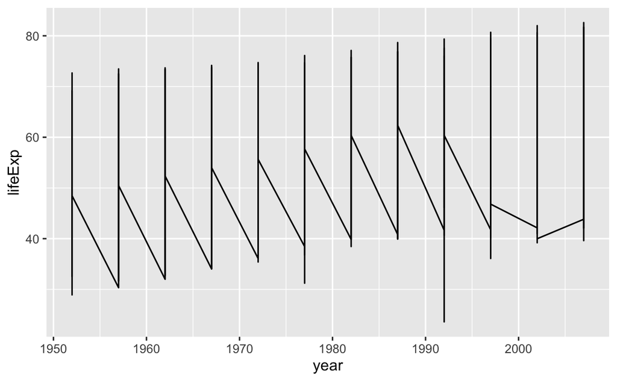

```r
ggplot(df, aes(x = year, y = lifeExp)) + geom_line()
```

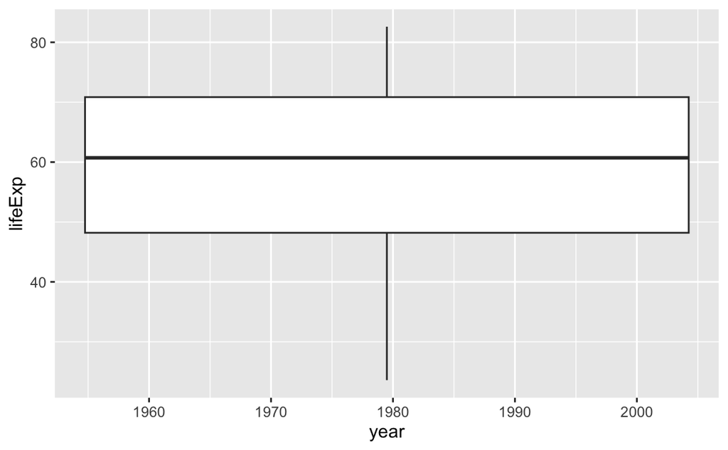

```r
ggplot(df, aes(x = year, y = lifeExp)) + geom_boxplot()
```

```r
typeof(pull(df, year)) # same as typeof(df$year)
```

```
[1] "integer"
```

### 3.2.1 Box Plot

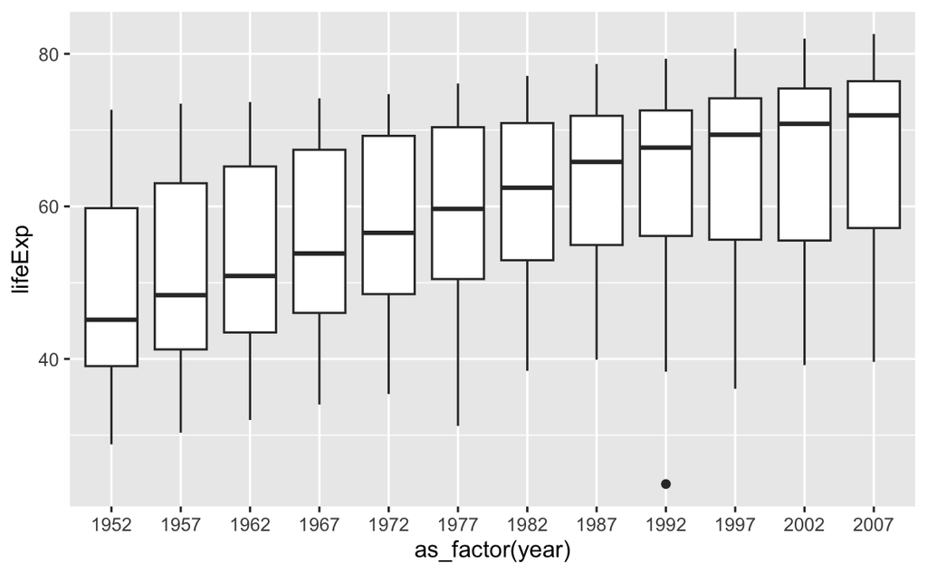

```r
ggplot(df, aes(x = as_factor(year), y = lifeExp)) + geom_boxplot()
```

## 3.3 Applications of `dplyr`

### 3.3.1 `filter`

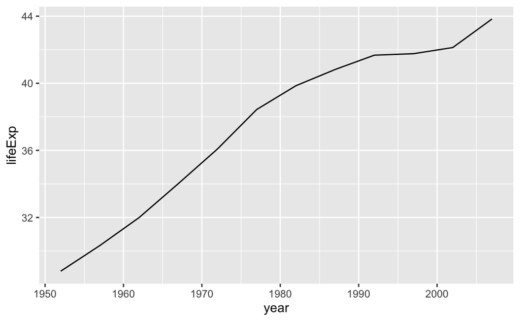

```r
df %>% filter(country == "Afghanistan") %>%
  ggplot(aes(x = year, y = lifeExp)) + geom_line()
```

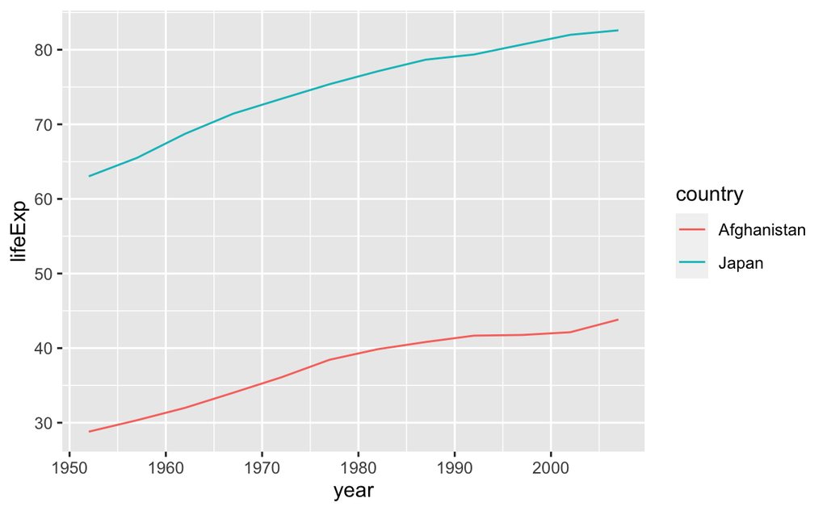

```r
df %>% filter(country %in% c("Afghanistan", "Japan")) %>%
  ggplot(aes(x = year, y = lifeExp, color = country)) + geom_line()
```

```r
df %>% distinct(country) %>% pull()
```

```
  [1] Afghanistan              Albania                  Algeria
  [4] Angola                   Argentina                Australia
  [7] Austria                  Bahrain                  Bangladesh
 [10] Belgium                  Benin                    Bolivia
 [13] Bosnia and Herzegovina   Botswana                 Brazil
 [16] Bulgaria                 Burkina Faso             Burundi
 [19] Cambodia                 Cameroon                 Canada
 [22] Central African Republic Chad                     Chile
 [25] China                    Colombia                 Comoros
 [28] Congo, Dem. Rep.         Congo, Rep.              Costa Rica
 [31] Cote d'Ivoire            Croatia                  Cuba
 [34] Czech Republic           Denmark                  Djibouti
 [37] Dominican Republic       Ecuador                  Egypt
 [40] El Salvador              Equatorial Guinea        Eritrea
 [43] Ethiopia                 Finland                  France
```

[output cut: 34 more lines]

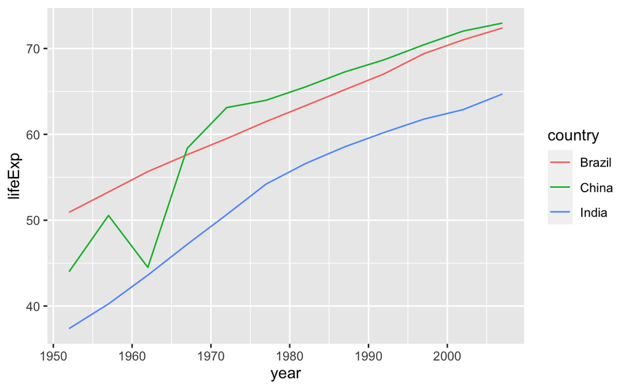

```r
df %>% filter(country %in% c("Brazil", "Russia", "India", "China")) %>%
  ggplot(aes(x = year, y = lifeExp, color = country)) + geom_line()
```

Russian data is missing.

### 3.3.2 Exercises

1. Change `lifeExp` to `pop` and `gdpPercap` and do the same.
2. Choose ASEAN countries and do the similar investigations.
- Brunei, Cambodia, Indonesia, Laos, Malaysia, Myanmar, Philippines, Singapore.
3. Choose several countries by yourself and do the similar investigations.

### 3.3.3 `group_by` and `summarize`

Let us use the variable `continent` and summarize the data.

```r
df_lifeExp <- df %>% group_by(continent, year) %>%
  summarize(mean_lifeExp = mean(lifeExp), median_lifeExp = median(lifeExp), max_lifeExp = max(lifeExp), min_lifeExp = min(lifeExp), .groups = "keep")
```

```r
df_lifeExp
```

| continent | year | mean_lifeExp | median_lifeExp | max_lifeExp | min_lifeExp |
| --- | --- | --- | --- | --- | --- |
| Africa | 1952 | 39.13550 | 38.8330 | 52.724 | 30.000 |
| Africa | 1957 | 41.26635 | 40.5925 | 58.089 | 31.570 |
| Africa | 1962 | 43.31944 | 42.6305 | 60.246 | 32.767 |
| Africa | 1967 | 45.33454 | 44.6985 | 61.557 | 34.113 |
| Africa | 1972 | 47.45094 | 47.0315 | 64.274 | 35.400 |
| Africa | 1977 | 49.58042 | 49.2725 | 67.064 | 36.788 |
| Africa | 1982 | 51.59287 | 50.7560 | 69.885 | 38.445 |
| Africa | 1987 | 53.34479 | 51.6395 | 71.913 | 39.906 |
| Africa | 1992 | 53.62958 | 52.4290 | 73.615 | 23.599 |
| Africa | 1997 | 53.59827 | 52.7590 | 74.772 | 36.087 |

[output cut: 50 more lines]

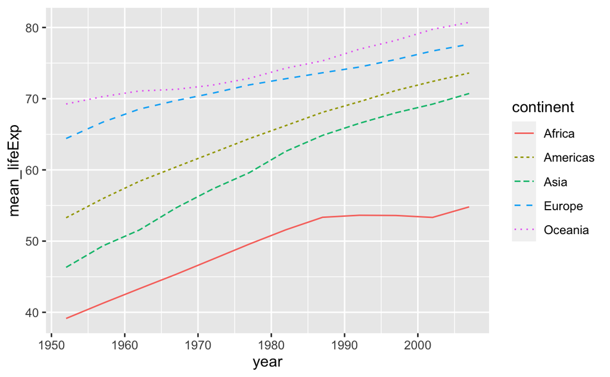

```r
df_lifeExp %>% ggplot(aes(x = year, y = mean_lifeExp, color = continent, linetype = continent)) +
  geom_line()
```

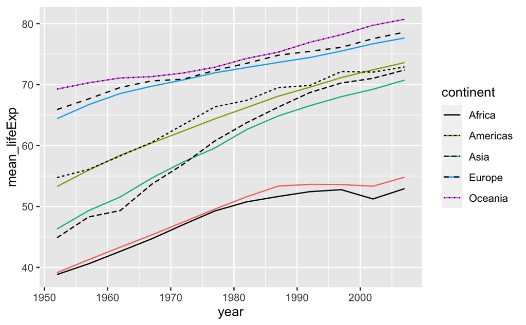

```r
df_lifeExp %>% ggplot() +
  geom_line(aes(x = year, y = mean_lifeExp, color = continent)) +
  geom_line(aes(x = year, y = median_lifeExp, linetype = continent))
```

# 4 Examples in Gapminer Package Help

```r
str(gapminder)
```

```
tibble [1,704 × 6] (S3: tbl_df/tbl/data.frame)
 $ country  : Factor w/ 142 levels "Afghanistan",..: 1 1 1 1 1 1 1 1 1 1 ...
 $ continent: Factor w/ 5 levels "Africa","Americas",..: 3 3 3 3 3 3 3 3 3 3 ...
 $ year     : int [1:1704] 1952 1957 1962 1967 1972 1977 1982 1987 1992 1997 ...
 $ lifeExp  : num [1:1704] 28.8 30.3 32 34 36.1 ...
 $ pop      : int [1:1704] 8425333 9240934 10267083 11537966 13079460 14880372 12881816 13867957 16317921 22227415 ...
 $ gdpPercap: num [1:1704] 779 821 853 836 740 ...
```

```r
head(gapminder)
```

| country | continent | year | lifeExp | pop | gdpPercap |
| --- | --- | --- | --- | --- | --- |
| Afghanistan | Asia | 1952 | 28.801 | 8425333 | 779.4453 |
| Afghanistan | Asia | 1957 | 30.332 | 9240934 | 820.8530 |
| Afghanistan | Asia | 1962 | 31.997 | 10267083 | 853.1007 |
| Afghanistan | Asia | 1967 | 34.020 | 11537966 | 836.1971 |
| Afghanistan | Asia | 1972 | 36.088 | 13079460 | 739.9811 |
| Afghanistan | Asia | 1977 | 38.438 | 14880372 | 786.1134 |

```r
summary(gapminder)
```

```
        country        continent        year         lifeExp           pop
 Afghanistan:  12   Africa  :624   Min.   :1952   Min.   :23.60   Min.   :6.001e+04
 Albania    :  12   Americas:300   1st Qu.:1966   1st Qu.:48.20   1st Qu.:2.794e+06
 Algeria    :  12   Asia    :396   Median :1980   Median :60.71   Median :7.024e+06
 Angola     :  12   Europe  :360   Mean   :1980   Mean   :59.47   Mean   :2.960e+07
 Argentina  :  12   Oceania : 24   3rd Qu.:1993   3rd Qu.:70.85   3rd Qu.:1.959e+07
 Australia  :  12                  Max.   :2007   Max.   :82.60   Max.   :1.319e+09
 (Other)    :1632
   gdpPercap
 Min.   :   241.2
 1st Qu.:  1202.1
 Median :  3531.8
 Mean   :  7215.3
 3rd Qu.:  9325.5
 Max.   :113523.1
```

```r
table(gapminder$continent)
```

```
  Africa Americas     Asia   Europe  Oceania
     624      300      396      360       24
```

```r
aggregate(lifeExp ~ continent, gapminder, median)
```

| continent | lifeExp |
| --- | --- |
| Africa | 47.7920 |
| Americas | 67.0480 |
| Asia | 61.7915 |
| Europe | 72.2410 |
| Oceania | 73.6650 |

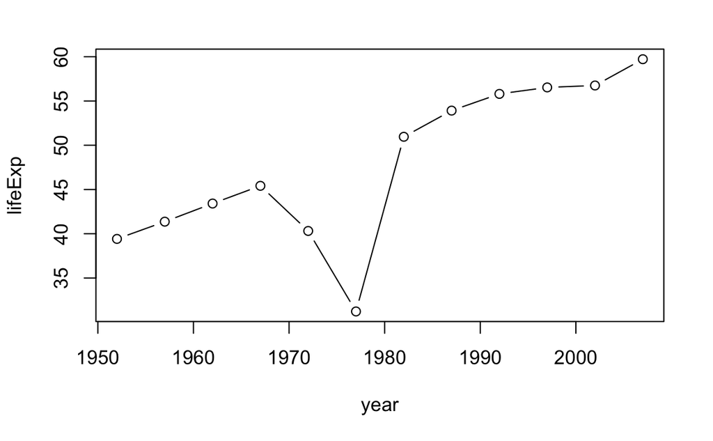

```r
plot(lifeExp ~ year, gapminder, subset = country == "Cambodia", type = "b")
```

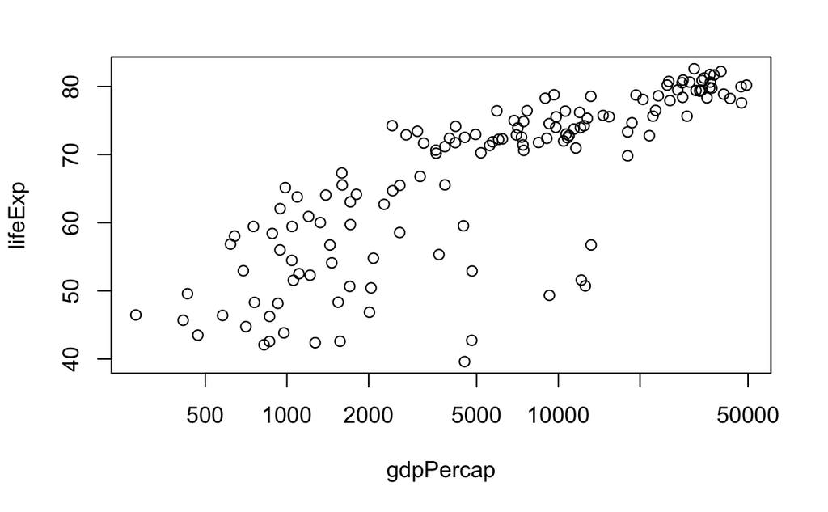

```r
plot(lifeExp ~ gdpPercap, gapminder, subset = year == 2007, log = "x")
```

```r
gapminder %>%
  filter(year == 2007) %>%
  group_by(continent) %>%
  summarise(lifeExp = median(lifeExp))
```

| continent | lifeExp |
| --- | --- |
| Africa | 52.9265 |
| Americas | 72.8990 |
| Asia | 72.3960 |
| Europe | 78.6085 |
| Oceania | 80.7195 |

How many unique countries does the data contain, by continent?

```r
gapminder %>%
  group_by(continent) %>%
  summarize(n_obs = n(), n_countries = n_distinct(country))
```

| continent | n_obs | n_countries |
| --- | --- | --- |
| Africa | 624 | 52 |
| Americas | 300 | 25 |
| Asia | 396 | 33 |
| Europe | 360 | 30 |
| Oceania | 24 | 2 |

By continent, which country experienced the sharpest 5-year drop in life expectancy and what was the drop?

```r
gapminder %>%
  group_by(continent, country) %>%
  select(country, year, continent, lifeExp) %>%
  mutate(le_delta = lifeExp - lag(lifeExp)) %>%
  summarize(worst_le_delta = min(le_delta, na.rm = TRUE)) %>%
  filter(min_rank(worst_le_delta) < 2) %>%
  arrange(worst_le_delta)
```

| continent | country | worst_le_delta |
| --- | --- | --- |
| Africa | Rwanda | -20.421 |
| Asia | Cambodia | -9.097 |
| Americas | El Salvador | -1.511 |
| Europe | Montenegro | -1.464 |
| Oceania | Australia | 0.170 |

# 5 Additional Exploration Using Tidyverse

# 6 World Development Indicators (WDI)

- SP.DYN.LE00.IN: Life expectancy at birth, total (years)
- NY.GDP.PCAP.KD: GDP per capita (constant 2015 US$)
- SP.POP.TOTL: Population, total

```r
df_wdi <- WDI(
  country = "all",
  indicator = c(lifeExp = "SP.DYN.LE00.IN", pop = "SP.POP.TOTL", gdpPercap = "NY.GDP.PCAP.KD")
)
```

```r
df_wdi
```

| country | iso2c | iso3c | year | lifeExp | pop | gdpPercap |
| --- | --- | --- | --- | --- | --- | --- |
| Afghanistan | AF | AFG | 1960 | 32.44600 | 8996967 | NA |
| Afghanistan | AF | AFG | 1961 | 32.96200 | 9169406 | NA |
| Afghanistan | AF | AFG | 1962 | 33.47100 | 9351442 | NA |
| Afghanistan | AF | AFG | 1963 | 33.97100 | 9543200 | NA |
| Afghanistan | AF | AFG | 1964 | 34.46300 | 9744772 | NA |
| Afghanistan | AF | AFG | 1965 | 34.94800 | 9956318 | NA |
| Afghanistan | AF | AFG | 1966 | 35.43000 | 10174840 | NA |
| Afghanistan | AF | AFG | 1967 | 35.91400 | 10399936 | NA |
| Afghanistan | AF | AFG | 1968 | 36.40300 | 10637064 | NA |
| Afghanistan | AF | AFG | 1969 | 36.90000 | 10893772 | NA |

[output cut: 990 more lines]

```r
df_wdi_extra <- WDI(
  country = "all",
  indicator = c(lifeExp = "SP.DYN.LE00.IN", pop = "SP.POP.TOTL", gdpPercap = "NY.GDP.PCAP.KD"),
  extra = TRUE
)
```

```r
df_wdi_extra
```

| country | iso2c | iso3c | year | status | lastupdated | lifeExp | pop | gdpPercap | region | capital | longitude | latitude | income | lending |
| --- | --- | --- | --- | --- | --- | --- | --- | --- | --- | --- | --- | --- | --- | --- |
| Afghanistan | AF | AFG | 1993 |  | 2022-09-16 | 52.25600 | 15816601 | NA | South Asia | Kabul | 69.1761 | 34.5228 | Low income | IDA |
| Afghanistan | AF | AFG | 1997 |  | 2022-09-16 | 54.42400 | 19357126 | NA | South Asia | Kabul | 69.1761 | 34.5228 | Low income | IDA |
| Afghanistan | AF | AFG | 1994 |  | 2022-09-16 | 52.84200 | 17075728 | NA | South Asia | Kabul | 69.1761 | 34.5228 | Low income | IDA |
| Afghanistan | AF | AFG | 1995 |  | 2022-09-16 | 53.39800 | 18110662 | NA | South Asia | Kabul | 69.1761 | 34.5228 | Low income | IDA |
| Afghanistan | AF | AFG | 2001 |  | 2022-09-16 | 56.30800 | 21606992 | NA | South Asia | Kabul | 69.1761 | 34.5228 | Low income | IDA |
| Afghanistan | AF | AFG | 1998 |  | 2022-09-16 | 54.90600 | 19737770 | NA | South Asia | Kabul | 69.1761 | 34.5228 | Low income | IDA |
| Afghanistan | AF | AFG | 1999 |  | 2022-09-16 | 55.37600 | 20170847 | NA | South Asia | Kabul | 69.1761 | 34.5228 | Low income | IDA |
| Afghanistan | AF | AFG | 2007 |  | 2022-09-16 | 59.37500 | 27100542 | 392.7105 | South Asia | Kabul | 69.1761 | 34.5228 | Low income | IDA |
| Afghanistan | AF | AFG | 2008 |  | 2022-09-16 | 59.93000 | 27722281 | 398.9711 | South Asia | Kabul | 69.1761 | 34.5228 | Low income | IDA |
| Afghanistan | AF | AFG | 1980 |  | 2022-09-16 | 43.24400 | 13356500 | NA | South Asia | Kabul | 69.1761 | 34.5228 | Low income | IDA |

[output cut: 990 more lines]

```r
WDIsearch(string="gdp per capita", field="name", short=FALSE, cache=NULL)
```

|  | indicator | name | description | sourceDatabase | sourceOrganization |
| --- | --- | --- | --- | --- | --- |
| 717 | 6.0.GDPpc_constant | GDP per capita, PPP (constant 2011 international $) | GDP per capita based on purchasing power parity (PPP). PPP GDP is gross domestic product converted to international dollars using purchasing power parity rates. An international dollar has the same pu… | LAC Equity Lab | World Development Indicators (World Bank) |
| 2271 | CC.GHG.MEMG.GC | Macro drivers of GHG emissions growth in the period 2012-2018 - GDP per capita | Data reflects the impact of GDP-per capita (as a macro-driver) to total emission growth (excluding LUCF) across the period 2012-2018. This data has been calculated by World Bank staff using greenhouse… | Country Climate and Development Report (CCDR) | Climate Watch. 2020. Washington, DC: World Resources Institute. Available online at: https://www.climatewatchdata.org. |
| 6236 | FB.DPT.INSU.PC.ZS | Deposit insurance coverage (% of GDP per capita) |  | WDI Database Archives |  |
| 11209 | NV.AGR.PCAP.KD.ZG | Real agricultural GDP per capita growth rate (%) | The growth rate of real per capita GDP in agriculture, expressed at an annual rate. | Africa Development Indicators | World Bank country economists. |
| 11429 | NY.GDP.PCAP.CD | GDP per capita (current US$) | GDP per capita is gross domestic product divided by midyear population. GDP is the sum of gross value added by all resident producers in the economy plus any product taxes and minus any subsidies not … | World Development Indicators | World Bank national accounts data, and OECD National Accounts data files. |
| 11430 | NY.GDP.PCAP.CN | GDP per capita (current LCU) | GDP per capita is gross domestic product divided by midyear population. GDP is the sum of gross value added by all resident producers in the economy plus any product taxes and minus any subsidies not … | World Development Indicators | World Bank national accounts data, and OECD National Accounts data files. |
| 11431 | NY.GDP.PCAP.KD | GDP per capita (constant 2015 US$) | GDP per capita is gross domestic product divided by midyear population. GDP is the sum of gross value added by all resident producers in the economy plus any product taxes and minus any subsidies not … | World Development Indicators | World Bank national accounts data, and OECD National Accounts data files. |
| 11432 | NY.GDP.PCAP.KD.ZG | GDP per capita growth (annual %) | Annual percentage growth rate of GDP per capita based on constant local currency. GDP per capita is gross domestic product divided by midyear population. GDP at purchaser's prices is the sum of gross … | World Development Indicators | World Bank national accounts data, and OECD National Accounts data files. |
| 11433 | NY.GDP.PCAP.KN | GDP per capita (constant LCU) | GDP per capita is gross domestic product divided by midyear population. GDP at purchaser's prices is the sum of gross value added by all resident producers in the economy plus any product taxes and mi… | World Development Indicators | World Bank national accounts data, and OECD National Accounts data files. |
| 11434 | NY.GDP.PCAP.PP.CD | GDP per capita, PPP (current international $) | This indicator provides per capita values for gross domestic product (GDP) expressed in current international dollars converted by purchasing power parity (PPP) conversion factor. GDP is the sum of gr… | World Development Indicators | International Comparison Program, World Bank \| World Development Indicators database, World Bank \| Eurostat-OECD PPP Programme. |

[output cut: 17 more lines]

```r
WDIsearch(string="life expectancy", field="name", short=FALSE, cache=NULL)
```

|  | indicator | name | description | sourceDatabase | sourceOrganization |
| --- | --- | --- | --- | --- | --- |
| 15750 | SE.SCH.LIFE | School life expectancy, primary to tertiary, both sexes (years) | Number of years a person of school entrance age can expect to spend within the specified level of education. For a child of a certain age a, the school life expectancy is calculated as the sum of the … | Education Statistics | UNESCO Institute for Statistics |
| 15751 | SE.SCH.LIFE.FE | School life expectancy, primary to tertiary, female (years) | Number of years a person of school entrance age can expect to spend within the specified level of education. For a child of a certain age a, the school life expectancy is calculated as the sum of the … | Education Statistics | UNESCO Institute for Statistics |
| 15752 | SE.SCH.LIFE.MA | School life expectancy, primary to tertiary, male (years) | Number of years a person of school entrance age can expect to spend within the specified level of education. For a child of a certain age a, the school life expectancy is calculated as the sum of the … | Education Statistics | UNESCO Institute for Statistics |
| 17307 | SP.DYN.LE00.FE.IN | Life expectancy at birth, female (years) | Life expectancy at birth indicates the number of years a newborn infant would live if prevailing patterns of mortality at the time of its birth were to stay the same throughout its life. | World Development Indicators | (1) United Nations Population Division. World Population Prospects: 2019 Revision. (2) Census reports and other statistical publications from national statistical offices, (3) Eurostat: Demographic St… |
| 17308 | SP.DYN.LE00.IN | Life expectancy at birth, total (years) | Life expectancy at birth indicates the number of years a newborn infant would live if prevailing patterns of mortality at the time of its birth were to stay the same throughout its life. | World Development Indicators | (1) United Nations Population Division. World Population Prospects: 2019 Revision, or derived from male and female life expectancy at birth from sources such as: (2) Census reports and other statistic… |
| 17309 | SP.DYN.LE00.MA.IN | Life expectancy at birth, male (years) | Life expectancy at birth indicates the number of years a newborn infant would live if prevailing patterns of mortality at the time of its birth were to stay the same throughout its life. | World Development Indicators | (1) United Nations Population Division. World Population Prospects: 2019 Revision. (2) Census reports and other statistical publications from national statistical offices, (3) Eurostat: Demographic St… |
| 17310 | SP.DYN.LE60.FE.IN | Life expectancy at age 60, female (years) | Life expectancy at age 60, female is the average number of years that a female at age 60 would live if prevailing patterns of mortality at the time of age 60 were to stay the same throughout her life. | Gender Statistics | 2019 World Population Prospects, United Nations Population Division: Retrieved August 31, 2020. |
| 17311 | SP.DYN.LE60.MA.IN | Life expectancy at age 60, male (years) | Life expectancy at age 60, male is the average number of years that a male at age 60 would live if prevailing patterns of mortality at the time of age 60 were to stay the same throughout his life. | Gender Statistics | 2019 World Population Prospects, United Nations Population Division: Retrieved August 31, 2020. |
| 17312 | SP.DYN.LIFE.MF | Life Expectancy at Birth(years) |  | WDI Database Archives |  |
| 19923 | UIS.SLE.02 | School life expectancy, pre-primary, both sexes (years) |  | Education Statistics |  |

[output cut: 28 more lines]

```r
WDIsearch(string="population, total", field="name", short=FALSE, cache=NULL)
```

|  | indicator | name | description | sourceDatabase | sourceOrganization |
| --- | --- | --- | --- | --- | --- |
| 9659 | JI.POP.URBN.ZS | Urban population, total (% of total population) |  | Global Jobs Indicators Database (JOIN) |  |
| 17674 | SP.POP.TOTL | Population, total | Total population is based on the de facto definition of population, which counts all residents regardless of legal status or citizenship. The values shown are midyear estimates. | World Development Indicators | (1) United Nations Population Division. World Population Prospects: 2019 Revision. (2) Census reports and other statistical publications from national statistical offices, (3) Eurostat: Demographic St… |

There are a lot of missing data. Can you do similar investigations as we did using `gapminder` package?

```r
df_wdi %>% distinct(country) %>% pull()
```

```
  [1] "Afghanistan"
  [2] "Africa Eastern and Southern"
  [3] "Africa Western and Central"
  [4] "Albania"
  [5] "Algeria"
  [6] "American Samoa"
  [7] "Andorra"
  [8] "Angola"
  [9] "Antigua and Barbuda"
 [10] "Arab World"
 [11] "Argentina"
 [12] "Armenia"
 [13] "Aruba"
 [14] "Australia"
 [15] "Austria"
```

[output cut: 251 more lines]

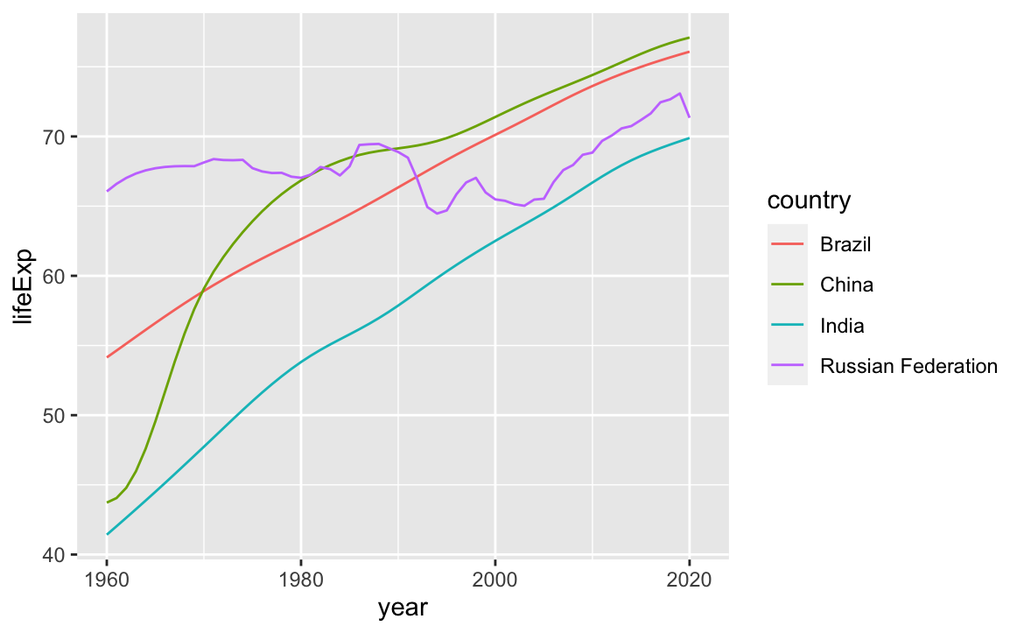

```r
df_wdi %>% filter(country %in% c("Brazil", "Russian Federation", "India", "China")) %>%
  ggplot(aes(x = year, y = lifeExp, color = country)) + geom_line()
```

```r
df_wdi_lifeExp <- df_wdi_extra %>% group_by(region, year) %>%
  summarize(mean_lifeExp = mean(lifeExp), median_lifeExp = median(lifeExp), max_lifeExp = max(lifeExp), min_lifeExp = min(lifeExp), .groups = "keep")
```

```r
df_wdi_lifeExp
```

| region | year | mean_lifeExp | median_lifeExp | max_lifeExp | min_lifeExp |
| --- | --- | --- | --- | --- | --- |
| Aggregates | 1960 | 51.00714 | 47.28433 | 69.89360 | 37.20538 |
| Aggregates | 1961 | 51.50759 | 47.79643 | 70.36802 | 37.63255 |
| Aggregates | 1962 | 51.93026 | 48.38454 | 70.23271 | 38.05261 |
| Aggregates | 1963 | 52.42594 | 49.08684 | 70.05039 | 38.46375 |
| Aggregates | 1964 | 52.99072 | 49.89707 | 70.31321 | 38.86707 |
| Aggregates | 1965 | 53.53114 | 50.85878 | 70.36672 | 39.26484 |
| Aggregates | 1966 | 54.10497 | 52.25728 | 70.60486 | 39.66276 |
| Aggregates | 1967 | 54.63397 | 53.58272 | 70.74399 | 40.06641 |
| Aggregates | 1968 | 55.11891 | 54.27410 | 70.79341 | 40.48283 |
| Aggregates | 1969 | 55.58613 | 54.85266 | 70.79960 | 40.91422 |

[output cut: 548 more lines]

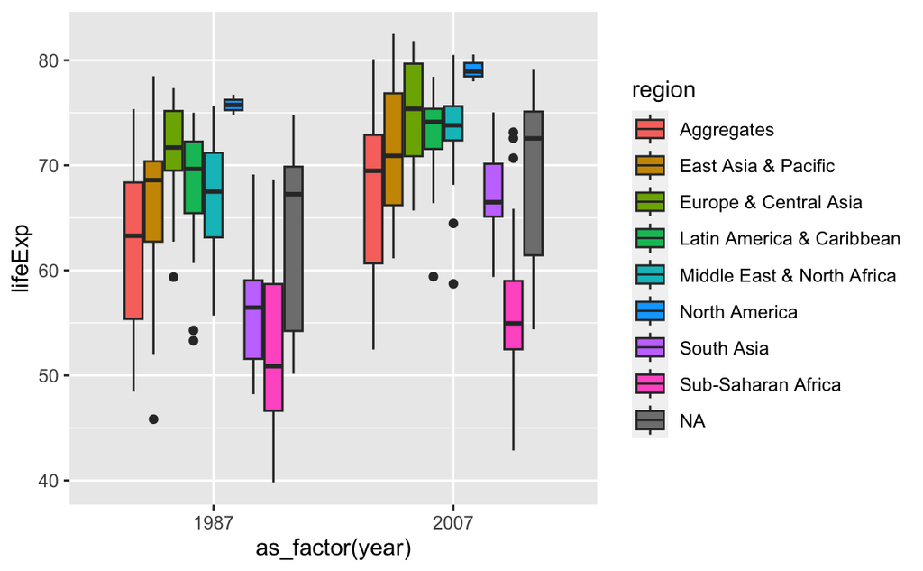

```r
df_wdi_extra %>% filter(year %in% c(1952, 1987, 2007)) %>%
  ggplot(aes(x=as_factor(year), y = lifeExp, fill = region)) +
  geom_boxplot()
```

Only with not NA values.

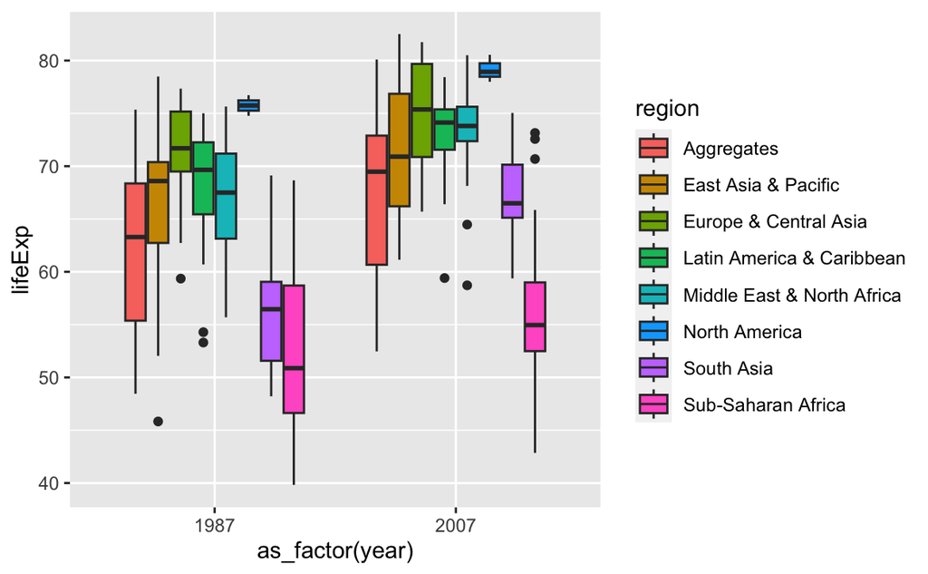

```r
df_wdi_extra %>% filter(year %in% c(1952, 1987, 2007), !is.na(lifeExp), !is.na(region)) %>%
  ggplot(aes(x=as_factor(year), y = lifeExp, fill = region)) +
  geom_boxplot()
```

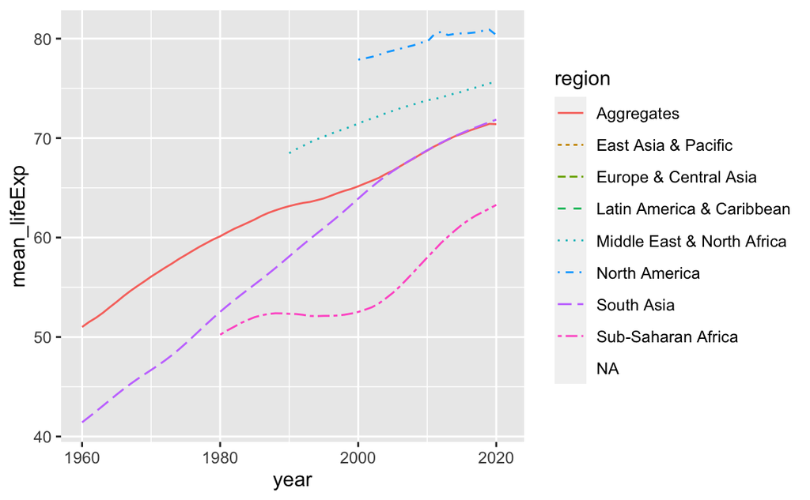

```r
df_wdi_lifeExp %>% ggplot(aes(x = year, y = mean_lifeExp, color = region, linetype = region)) +
  geom_line()
```

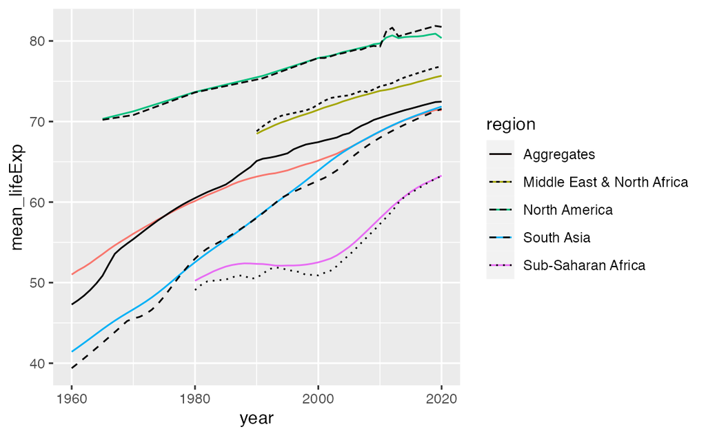

```r
df_wdi_lifeExp %>%
  filter(!is.na(mean_lifeExp), !is.na(median_lifeExp)) %>%
  ggplot() +
  geom_line(aes(x = year, y = mean_lifeExp, color = region)) +
  geom_line(aes(x = year, y = median_lifeExp, linetype = region))
```